##### This is a python script to evaluate various machine learning models and pick the best model to classify HLA class of peptides (i.e. Class I or Class II)

###### Import modules

```
import pandas as pd
import numpy as np
import scipy as sp
from pandas import scatter_matrix
import seaborn as sns
import matplotlib.pyplot as plt
import sklearn
from sklearn import model_selection
from sklearn.metrics import accuracy_score
from sklearn.metrics import confusion_matrix
from sklearn.metrics import classification_report
from sklearn.linear_model import LogisticRegression
from sklearn.tree import DecisionTreeClassifier
from sklearn.neighbors import KNeighborsClassifier
from sklearn.discriminant_analysis import LinearDiscriminantAnalysis
from sklearn.naive_bayes import GaussianNB
from sklearn.svm import SVC
from sklearn.ensemble import RandomForestClassifier
import random
```

###### Import dataset and perform exploratory data analysis

```
# Read the Dataset
dataset = pd.read_csv('all_pep_final.csv')

# Get dimension
dataset.shape
```

```
(5856, 14)
```

```
# Get column names
dataset.columns
```

```
Index(['Peptide', '-10lgP', 'Mass',
'Length', 'ppm', 'm/z', 'RT',
'Area',
       'Fraction', 'Scan', 'Source File',
'#Spec', 'Accession', 'HLA_Class'],
      dtype='object')
```

```
# Only keep Mass, length, m/z, RT, and HLA_Class columns
dat = dataset[['Mass', 'Length', 'm/z', 'RT', 'HLA_Class']]

# Since there is a class bias...i.e. more class I peptides than class II we need to make them equal
dat.HLA_Class.value_counts()
```

```
Class I     4013
Class II    1843
Name: HLA_Class, dtype: int64
```

###### There are two ways of treating this class bias, one is to randomly select 1843 Class I peptides....Another is to select exactly same percentage of training set of class II. Here we will just randomly select 1843 class I peptides.

```
random_1843_classI = dat[dat.HLA_Class == 'Class I'].sample(1843)
working_dataset = random_1843_classI.append(dat[dat.HLA_Class == 'Class II'])
working_dataset.shape
```

```
(3686, 5)
```

```
# Now that we have a working dataset with no class bias, lets go ahead and do some EDA
# Get summary to have an overall idea of the dataset
working_dataset.describe()
```

|  | Mass | Length | m/z | RT |
| --- | --- | --- | --- | --- |
| count | 3686.000000 | 3686.000000 | 3686.000000 | 3686.000000 |
| mean | 1322.693690 | 11.930277 | 562.094175 | 40.587925 |
| std | 391.251319 | 3.634938 | 123.347086 | 10.948514 |
| min | 486.280200 | 5.000000 | 304.850900 | 18.430000 |
| 25% | 1018.814275 | 9.000000 | 485.312650 | 32.540000 |
| 50% | 1158.127450 | 10.000000 | 535.804850 | 39.460000 |
| 75% | 1619.836100 | 15.000000 | 615.853525 | 47.207500 |
| max | 3714.918900 | 35.000000 | 1058.040000 | 76.400000 |

```
# Double check class bias
working_dataset.groupby('HLA_Class').size()
```

```
HLA_Class
Class I     1843
Class II    1843
dtype: int64
```

```
# Boxplot of variables
working_dataset.plot(kind = 'box')
```

```
<matplotlib.axes._subplots.AxesSubplot at 0x1a0a084588>
```

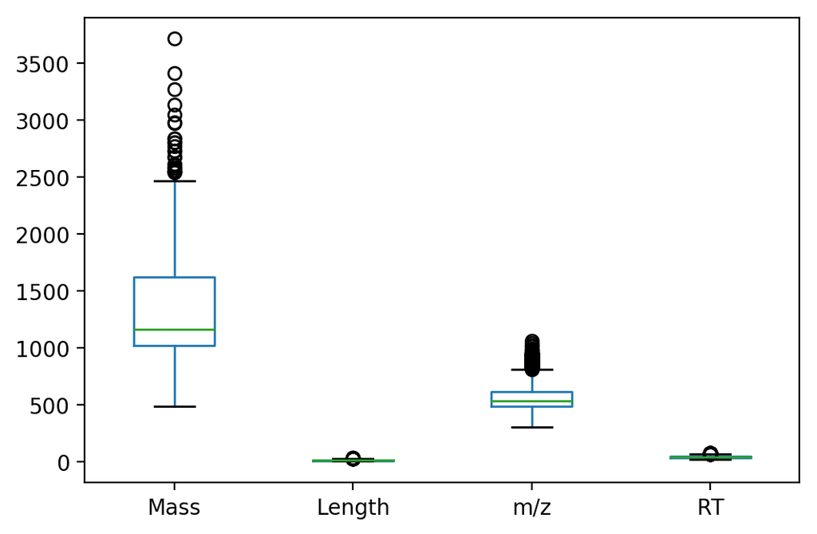

```
# Pairplot to have a general idea of correlations of variables
sns.pairplot(working_dataset)
```

```
<seaborn.axisgrid.PairGrid at 0x1a0a06c0b8>
```

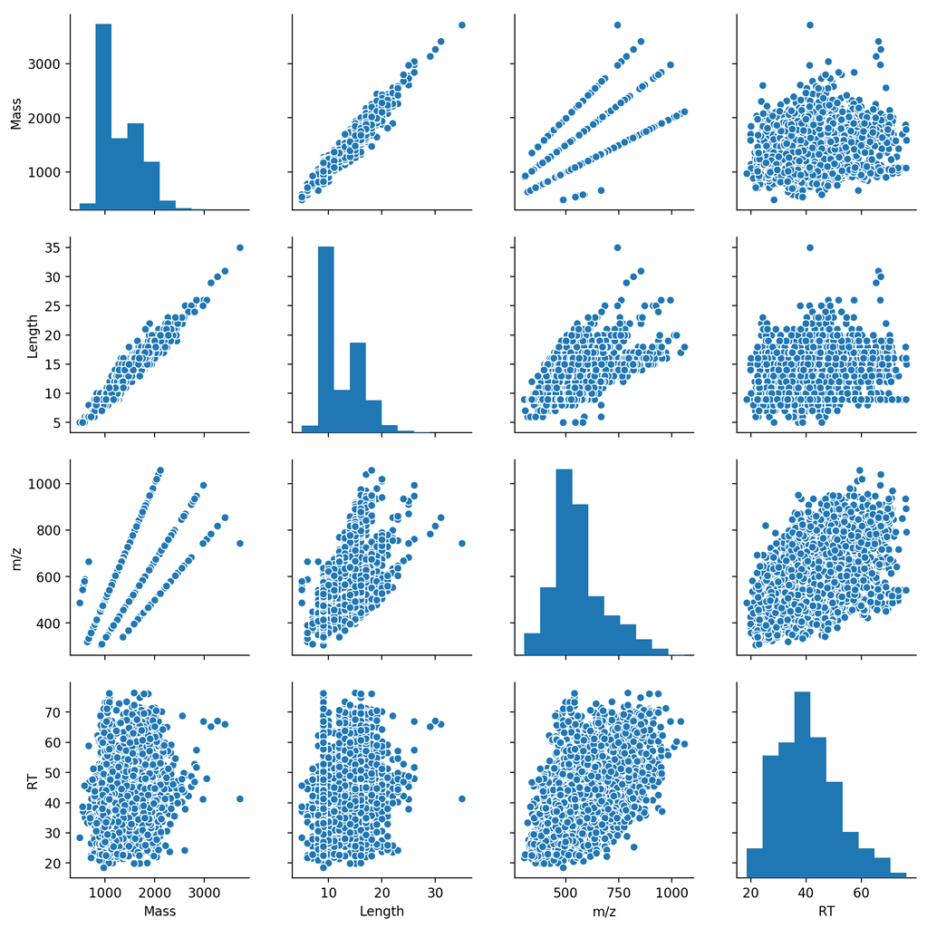

###### Evaluate some algorithms to this classification problem

###### First separate the dataset into train and test sets

```
array =  working_dataset.values
X = array[:, 0:4] # all independent values
Y = array[:, 4] # dependent or response value
validation_size = 0.20 # 20 % for this instance
seed = 123
X_train, X_validation, Y_train, Y_validation = model_selection.train_test_split(X, Y, test_size = validation_size,
random_state = seed)
# numpy array objects are created by train_test_split function
# Set seed again and assign 'accuracy' to scoring variable because KFold function below will
# give accuracy values that we need to assign to scoring parameterself.
seed = 123
scoring = 'accuracy'
```

###### Build the models together and compare accuracy

```
# We will build 7 different models for this classification problem . They are :
# Logistic Regression (LR)
# Linear Discriminant Analysis (LDA)
# K-Nearest Neighbors (KNN).
# Classification and Regression Trees (CART).
# Gaussian Naive Bayes (NB).
# Support Vector Machines (SVM).
# RandomForestClassifier (RF)

models = []
models.append(('LR', LogisticRegression()))
models.append(('LDR', LinearDiscriminantAnalysis()))
models.append(('KNN', KNeighborsClassifier()))
models.append(('CART', DecisionTreeClassifier()))
models.append(('NB', GaussianNB()))
models.append(('SVM', SVC()))
models.append(('RF', RandomForestClassifier()))
```

###### Build the models sequentially and evaluate their accuracy with the model_selection function.Remember validation set will not be used here . We will use 10 fold cross validation method to generate cv score and scoring values for model_selection.cross_val_score function below.

```
names = []
results = []
for name, model in models:
	kfold = model_selection.KFold(n_splits=10, random_state=seed)
	cv_results = model_selection.cross_val_score(model, X_train, Y_train, cv=kfold, scoring=scoring)
	results.append(cv_results)
	names.append(name)
	msg = "%s: %f (%f)" % (name, cv_results.mean(), cv_results.std())
	print(msg)
```

```
LR: 0.894170 (0.013076)
LDR: 0.887382 (0.013198)
KNN: 0.881954 (0.009681)
CART: 0.855842 (0.010540)
NB: 0.881952 (0.014619)
SVM: 0.773409 (0.023782)
RF: 0.886713 (0.015338)
```

```
# plot accuracy comparision of the models
plt.boxplot(results)
plt.show()
```

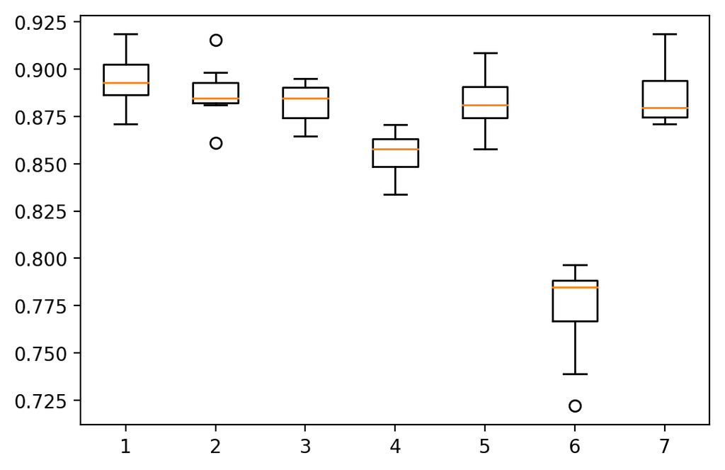

###### Logistic regression is the best model for this dataset ~ 89.5 % accuracy

###### LR is the best model for this HLA classification problem. Let's build this LR model and use it to predict class on our validation dataset

```
lr = LogisticRegression()
lr.fit(X_train, Y_train)
```

```
LogisticRegression(C=1.0, class_weight=None, dual=False,
fit_intercept=True,
          intercept_scaling=1, max_iter=100,
multi_class='ovr', n_jobs=1,
          penalty='l2', random_state=None,
solver='liblinear', tol=0.0001,
          verbose=0, warm_start=False)
```

```
predictions = lr.predict(X_validation)
print(accuracy_score(Y_validation, predictions))
```

```
0.8550135501355014
```

```
print(confusion_matrix(Y_validation, predictions))
```

```
[[339  23]
 [ 84 292]]
```

```
print(classification_report(Y_validation, predictions))
```

```
             precision    recall  f1-score   support

    Class I       0.80      0.94      0.86       362
   Class II       0.93      0.78      0.85       376

avg / total       0.87      0.86      0.85       738
```

###### Our model is almost 86% accurate with 87% precision, and recall & f1 score of 86%.

Published from HLA_Class_prediction.pmd using Pweave 0.30.3 on 21-02-2019.